# Mammal data - National

Talia Gabay & Ron Chen

2025-11-17

```r
P <- P_byplot
```

There are 53 sites total, Sites are located either near or far from Settlements or near or far from agriculture. Most sites have 2 plot types except for conifer forest and herbaceous and dwarf shrub vegetation (only far).

Inland sand also has a division according to dune status - shifting or semi-shifting.

Each site was sampled for all 5 monitoring cycles besides inland sands, where sites were monitored for 3 monitoring cycles (2,3,4)

Let’s first validate the data:

```r
#include rare species in analysis
P.anal <- copy(P) # set a fixed variable name for analysis, if want to switch between data WITH rare #species and data WITHOUT rare species then only change once here

#Validate factors and levels

P.anal$Settlements <- as.factor(P.anal$Settlements)
print("Settlements has 2 levels")
```

```
## [1] "Settlements has 2 levels"
```

```r
print(levels(P.anal$Settlements))
```

```
## [1] "Far"  "Near"
```

```r
P.anal$Agriculture <- as.factor(P.anal$Agriculture)
print("Agriculture has 2 levels")
```

```
## [1] "Agriculture has 2 levels"
```

```r
print(levels(P.anal$Agriculture))
```

```
## [1] "Far"  "Near"
```

```r
P.anal$Unit <- as.factor(P.anal$Unit)
print("Unit has 7 levels")
```

```
## [1] "Unit has 7 levels"
```

```r
print(levels(P.anal$Unit))
```

```
## [1] "Arid Desert"
## [2] "Herbaceous and Dwarf Shrub Vegetation"
## [3] "Inland Sands"
## [4] "Mediterranean Desert Transition Zone"
## [5] "Mediterranean Maquis"
## [6] "Negev Highlands"
## [7] "Planted Conifer Forests"
```

```r
P.anal$Site <- as.factor(P.anal$Site)
print("Site has 53 levels")
```

```
## [1] "Site has 53 levels"
```

```r
print(levels(P.anal$Site))
```

```
##  [1] "Aderet_conifer"          "Aderet_maquis"
##  [3] "Amatzia"                 "Bat Shlomo"
##  [5] "Beer Milka"              "Beit Oren"
##  [7] "Beit Yatir"              "Bislach"
##  [9] "Ein Yaakov"              "Ein Yahav"
## [11] "Eitanim"                 "Elyakim"
## [13] "Eshtaol"                 "Ezuz"
## [15] "Gamla"                   "Givat Yearim"
## [17] "Givat Yeshayahu_conifer" "Givat Yeshayahu_maquis"
## [19] "Goren"                   "Har Amasa"
## [21] "Iftach"                  "Kabri"
## [23] "Karei Deshe"             "Kerem Maharal_conifer"
## [25] "Kerem Maharal_maquis"    "Kfar Shamai"
## [27] "Kisalon"                 "Lahav"
## [29] "Lehavim"                 "Lotan"
## [31] "Manara"                  "Margaliot"
## [33] "Merhav Am"               "Meron"
## [35] "Mirsham"                 "Natur"
## [37] "Nehusha"                 "Nir Etzion"
## [39] "Ofer_conifer"            "Ofer_maquis"
## [41] "Paran"                   "Ramat Hashofet"
## [43] "Ramot Naftali"           "Sde Boker"
## [45] "Secher"                  "Shaal"
## [47] "Shunra"                  "Yagur"
## [49] "Yavneel"                 "Yeruham"
## [51] "Yotvata"                 "Zofar"
## [53] "Zuriel"
```

```r
P.anal$Transect <- as.factor(P.anal$Transect)
print("Transect has 88 levels")
```

```
## [1] "Transect has 88 levels"
```

```r
print(levels(P.anal$Transect))
```

```
##  [1] "Aderet_conifer Far"            "Aderet_maquis Far"
##  [3] "Aderet_maquis Near"            "Amatzia Far"
##  [5] "Bat Shlomo Far"                "Beer Milka Far Shifting 1"
##  [7] "Beer Milka Far Shifting 2"     "Beer Milka Far Shifting 3"
##  [9] "Beer Milka Near Semi-Shifting" "Beer Milka Near Shifting"
## [11] "Beit Oren Far"                 "Beit Oren Near"
## [13] "Beit Yatir Far"                "Beit Yatir Near"
## [15] "Bislach Far"                   "Bislach Near"
## [17] "Ein Yaakov Far"                "Ein Yaakov Near"
## [19] "Ein Yahav Far"                 "Ein Yahav Near"
## [21] "Eitanim Far"                   "Elyakim Far"
## [23] "Eshtaol Far"                   "Ezuz Far"
## [25] "Ezuz Near"                     "Gamla Far"
## [27] "Givat Yearim Far"              "Givat Yearim Near"
## [29] "Givat Yeshayahu_conifer Far"   "Givat Yeshayahu_maquis Far"
```

[output cut: 29 more lines]

```r
print("RICHNESS WITH RARE SPECIES")
```

```
## [1] "RICHNESS WITH RARE SPECIES"
```

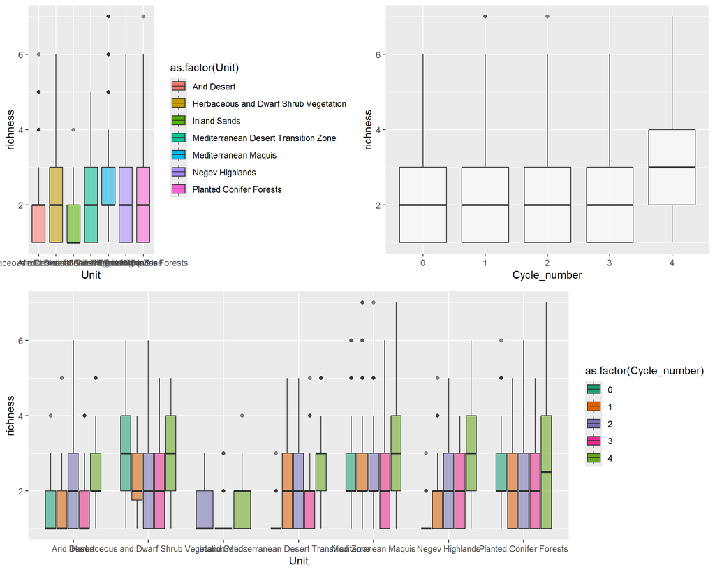

```r
plot_alpha_diversity(P, x_val = "Unit", y_val = "richness", ylab_val = "richness", xlab_val = "Unit", fill_val = "Unit")
```

```r
col_names <- c("Cycle_number",  "Deployment.id_new",    "Unit", "Subunit",  "Site", "Distance_rescaled", "Distance_agri_rescaled", "Year", "rescaled_Time.Diff", "sinus_Monitoring.Time.Diff", "cosinus_Monitoring.Time.Diff", "Transect", "Transect_with_date")

spp <- all.mammal.abundances[,27:40]
# filter out species with zero counts
print(colSums(spp))
```

```
##      Canis aureus       Canis lupus     Capra nubiana Dama mesopotamica
##             10512               407               405               353
##    Equus hemionus    Gazella dorcas   Gazella gazella     Hyaena hyaena
##               116              1006              2627               596
##    Hystrix indica    Lepus capensis       Meles meles     Oryx leucoryx
##              4488              1099               555                72
##        Sus scrofa     Vulpes vulpes
##             12737              4177
```

```
## Overlapping points were shifted along the y-axis to make them visible.
```

```
##
##  PIPING TO 2nd MVFACTOR
```

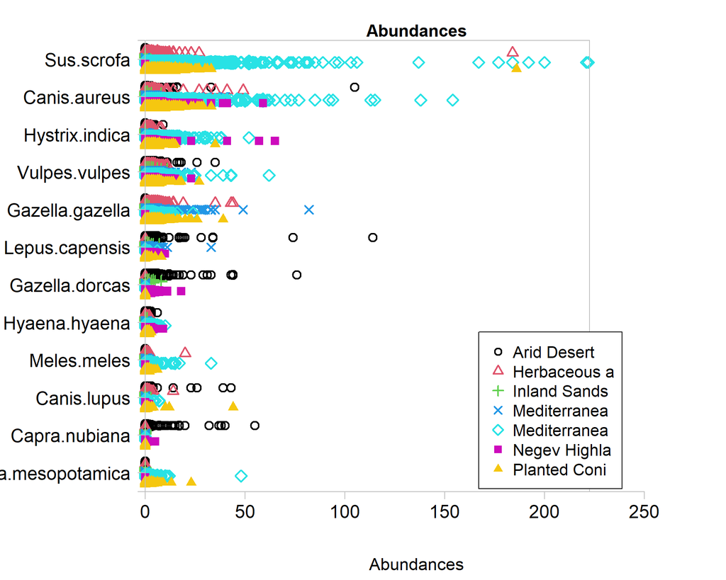

```
## Only the variables Sus.scrofa, Canis.aureus, Hystrix.indica, Vulpes.vulpes, Gazella.gazella, Lepus.capensis, Gazella.dorcas, Hyaena.hyaena, Meles.meles, Canis.lupus, Capra.nubiana, Dama.mesopotamica were included in the plot
## (the variables with highest total abundance).
```

```r
spp <- spp[,.SD,.SDcols = colSums(spp)>0]
spp <- mvabund(spp)

plot(spp ~ P.anal$Unit, overall.main="raw abundances", transformation = "no")
```

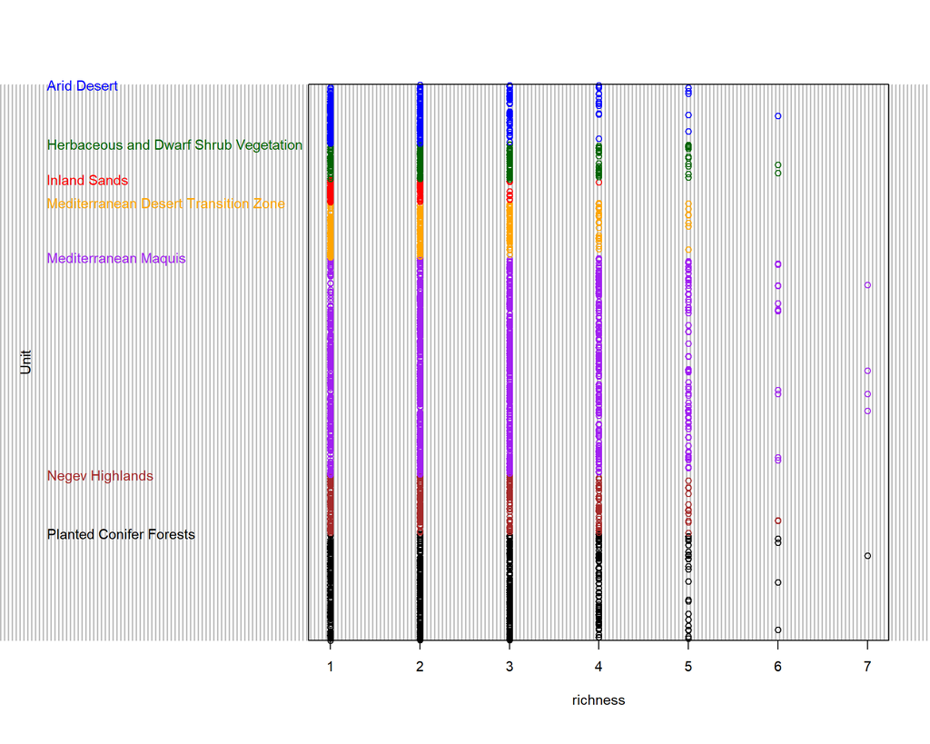

```r
my_cols <- c("blue", "darkgreen", "red", "orange", "purple", "brown", "black")
dotchart(P.anal$richness, ylab = "Unit",
         groups = P.anal$Unit, gcolor = my_cols,
         color = my_cols[P.anal$Unit],
         cex = 0.9,  pch = 1, xlab = "richness")
```

```r
kable(summary(P.anal[,.(richness, abundance, rescaled_Time.Diff, cosinus_Monitoring.Time.Diff, sinus_Monitoring.Time.Diff, Unit, Site, Transect, Distance_rescaled, Distance_agri_rescaled)]))
```

|  | richness | abundance | rescaled_Time.Diff | cosinus_Monitoring.Time.Diff | sinus_Monitoring.Time.Diff | Unit | Site | Transect | Distance_rescaled | Distance_agri_rescaled |
| --- | --- | --- | --- | --- | --- | --- | --- | --- | --- | --- |
|  | Min. :1.000 | Min. : 1.00 | Min. :-1.8927 | Min. :-0.999961 | Min. :-0.99999 | Arid Desert : 303 | Goren : 87 | Goren Near : 45 | Min. :-0.9136 | Min. :-0.68190 |
|  | 1st Qu.:1.000 | 1st Qu.: 2.00 | 1st Qu.:-0.8369 | 1st Qu.:-0.759688 | 1st Qu.:-0.60200 | Herbaceous and Dwarf Shrub Vegetation: 181 | Ein Yaakov : 85 | Ein Yaakov Near : 44 | 1st Qu.:-0.6715 | 1st Qu.:-0.54178 |
|  | Median :2.000 | Median : 7.00 | Median : 0.1421 | Median : 0.004426 | Median : 0.03540 | Inland Sands : 116 | Kfar Shamai: 84 | Bat Shlomo Far : 42 | Median :-0.2598 | Median :-0.32953 |
|  | Mean :2.349 | Mean : 13.75 | Mean : 0.0000 | Mean :-0.001424 | Mean : 0.03418 | Mediterranean Desert Transition Zone : 281 | Margaliot : 82 | Goren Far : 42 | Mean : 0.0000 | Mean : 0.00000 |
|  | 3rd Qu.:3.000 | 3rd Qu.: 16.00 | 3rd Qu.: 0.8057 | 3rd Qu.: 0.717964 | 3rd Qu.: 0.74511 | Mediterranean Maquis :1117 | Beer Milka : 81 | Kfar Shamai Far : 42 | 3rd Qu.: 0.2975 | 3rd Qu.: 0.03599 |
|  | Max. :7.000 | Max. :341.00 | Max. : 1.5246 | Max. : 1.000000 | Max. : 0.99999 | Negev Highlands : 298 | Iftach : 79 | Kfar Shamai Near: 42 | Max. : 7.0396 | Max. : 5.39389 |
|  | NA | NA | NA | NA | NA | Planted Conifer Forests : 551 | (Other) :2349 | (Other) :2590 | NA | NA |

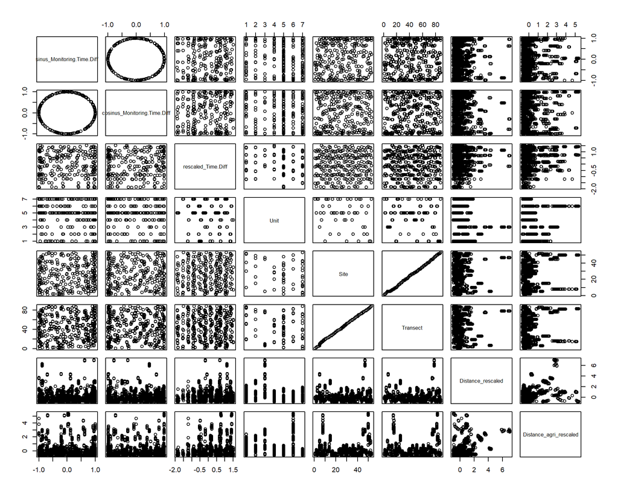

```r
pairs(P.anal[,lapply(X = .SD,FUN = as.numeric),.SDcols=c("sinus_Monitoring.Time.Diff", "cosinus_Monitoring.Time.Diff","rescaled_Time.Diff","Unit","Site","Transect", "Distance_rescaled", "Distance_agri_rescaled")])
```

```r
kable(cor(P.anal[,lapply(X = .SD,FUN = as.numeric),.SDcols=c("sinus_Monitoring.Time.Diff", "cosinus_Monitoring.Time.Diff","rescaled_Time.Diff","Unit","Site","Transect", "Distance_rescaled", "Distance_agri_rescaled")]))
```

|  | sinus_Monitoring.Time.Diff | cosinus_Monitoring.Time.Diff | rescaled_Time.Diff | Unit | Site | Transect | Distance_rescaled | Distance_agri_rescaled |
| --- | --- | --- | --- | --- | --- | --- | --- | --- |
| sinus_Monitoring.Time.Diff | 1.0000000 | 0.0456921 | -0.0460064 | -0.0473414 | 0.0616279 | 0.0639110 | -0.0020757 | 0.0033455 |
| cosinus_Monitoring.Time.Diff | 0.0456921 | 1.0000000 | 0.0828695 | -0.0533080 | 0.0576440 | 0.0589385 | -0.0292893 | 0.0580596 |
| rescaled_Time.Diff | -0.0460064 | 0.0828695 | 1.0000000 | -0.1460930 | 0.0365404 | 0.0370137 | 0.0917374 | 0.1407493 |
| Unit | -0.0473414 | -0.0533080 | -0.1460930 | 1.0000000 | -0.1967831 | -0.1995282 | -0.2546037 | -0.1026876 |
| Site | 0.0616279 | 0.0576440 | 0.0365404 | -0.1967831 | 1.0000000 | 0.9991463 | -0.0061128 | 0.0804922 |
| Transect | 0.0639110 | 0.0589385 | 0.0370137 | -0.1995282 | 0.9991463 | 1.0000000 | -0.0161084 | 0.0745040 |
| Distance_rescaled | -0.0020757 | -0.0292893 | 0.0917374 | -0.2546037 | -0.0061128 | -0.0161084 | 1.0000000 | 0.4155870 |
| Distance_agri_rescaled | 0.0033455 | 0.0580596 | 0.1407493 | -0.1026876 | 0.0804922 | 0.0745040 | 0.4155870 | 1.0000000 |

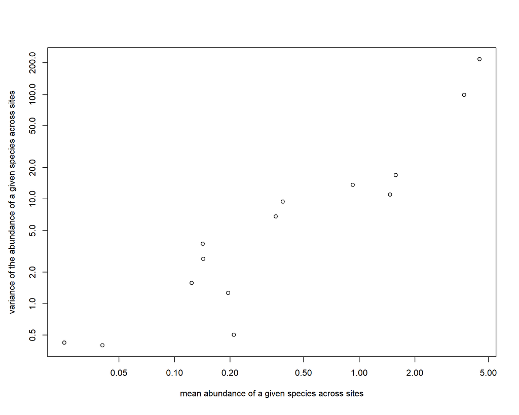

```r
meanvar.plot(spp, xlab = "mean abundance of a given species across sites", ylab = "variance of the abundance of a given species across sites")
```

```r
# mdl_r.poiss.int <- glm(data = P.anal, formula = richness ~ rescaled_Time.Diff + cosinus_Monitoring.Time.Diff + sinus_Monitoring.Time.Diff + Unit + Site + Transect, family = poisson)
# od <- mdl_r.poiss.int$deviance/mdl_r.poiss.int$df.residual
# print("Estimating overdispersion parameter phi: (Res. Dev.)/(n-p) where n=number of observations; p=number of parameters in the model.")
# print(paste0('od = ',od))
```

```r
# m0 <- glm(data = P.anal, formula =  richness ~ rescaled_Time.Diff + cosinus_Monitoring.Time.Diff + sinus_Monitoring.Time.Diff, family = poisson)
# AIC(m0)
#
# me0transect <- glmer(data = P.anal, formula =   richness ~  rescaled_Time.Diff + cosinus_Monitoring.Time.Diff + sinus_Monitoring.Time.Diff +  (1|Transect), family = poisson, verbose = 1)
# AIC(me0transect)
#
# me0site <- glmer(data = P.anal, formula =   richness ~ rescaled_Time.Diff + cosinus_Monitoring.Time.Diff + sinus_Monitoring.Time.Diff +  (1|Site), family = poisson, verbose = 1)
# AIC(me0site)
#
# me0unit <- glmer(data = P.anal, formula =   richness ~ rescaled_Time.Diff + cosinus_Monitoring.Time.Diff + sinus_Monitoring.Time.Diff +  (1|Unit), family = poisson, verbose = 1)
# AIC(me0unit)
```

```r
# m1 <- glmer(data = P.anal, formula =   richness ~ rescaled_Time.Diff + cosinus_Monitoring.Time.Diff + sinus_Monitoring.Time.Diff +  (1|Unit), family = poisson)
# drop1(m1)
```

```r
# m2 <- glmer(data = P.anal, formula =   richness ~ rescaled_Time.Diff + cosinus_Monitoring.Time.Diff + (1|Unit), family = poisson)
# drop1(m2)
```

```r
# summ(m2, exp = TRUE, digits=3)
# effect_plot(model = m2, data=P.anal, pred = rescaled_Time.Diff, interval = T, plot.points = F, jitter = c(0.1,0), point.size = 3, cat.pred.point.size = 4, partial.residuals = F, colors = "Qual1", main.title = "Temporal effect on species richness")
```

#### Community analysis using package MVabund

## Rare species filtering - minimum of 40 deployments

```r
abundance_and_cameras <- as.data.table(all.mammal.abundances[,c(5,27:40)])
dim(abundance_and_cameras)
```

```
## [1] 2847   15
```

```r
canisau <- abundance_and_cameras[,2] > 0
sum(canisau)
```

```
## [1] 1379
```

```r
canislup <- abundance_and_cameras[,3] > 0
sum(canislup)
```

```
## [1] 102
```

```r
capra <- abundance_and_cameras[,4] > 0
sum(capra)
```

```
## [1] 41
```

```r
Doma <- abundance_and_cameras[,5] > 0
sum(Doma)
```

```
## [1] 78
```

```r
Equus <- abundance_and_cameras[,6] > 0
sum(Equus)
```

```
## [1] 26
```

```r
Gazellador <- abundance_and_cameras[,7] > 0
sum(Gazellador)
```

```
## [1] 195
```

```r
Gazellagaz <- abundance_and_cameras[,8] > 0
sum(Gazellagaz)
```

```
## [1] 533
```

```r
Hyaena <- abundance_and_cameras[,9] > 0
sum(Hyaena)
```

```
## [1] 358
```

```r
Hystrix <- abundance_and_cameras[,10] > 0
sum(Hystrix)
```

```
## [1] 1030
```

```r
Lepus <- abundance_and_cameras[,11] > 0
sum(Lepus)
```

```
## [1] 277
```

```r
Meles <- abundance_and_cameras[,12] > 0
sum(Meles)
```

```
## [1] 274
```

```r
Oryx <- abundance_and_cameras[,13] > 0
sum(Oryx)
```

```
## [1] 8
```

```r
Sus <- abundance_and_cameras[,14] > 0
sum(Sus)
```

```
## [1] 1088
```

```r
Vulpus <- abundance_and_cameras[,15] > 0
sum(Vulpus)
```

```
## [1] 1298
```

2847 cameras total,

Species for national analyses + a minimum of 40 cameras - Canis aureus, Canis lupus, Hyaena hyaena, Hystrix indica, Lepus capensis and vulpus vulpus

```r
spp_no_rare <- all.mammal.abundances[,27:40]
print(colSums(spp_no_rare))
```

```
##      Canis aureus       Canis lupus     Capra nubiana Dama mesopotamica
##             10512               407               405               353
##    Equus hemionus    Gazella dorcas   Gazella gazella     Hyaena hyaena
##               116              1006              2627               596
##    Hystrix indica    Lepus capensis       Meles meles     Oryx leucoryx
##              4488              1099               555                72
##        Sus scrofa     Vulpes vulpes
##             12737              4177
```

```r
# filter out species
spp_no_rare <- mvabund(spp_no_rare[,c(-3:-7,-11:-13)])
print(colSums(spp_no_rare))
```

```
##   Canis.aureus    Canis.lupus  Hyaena.hyaena Hystrix.indica Lepus.capensis
##          10512            407            596           4488           1099
##  Vulpes.vulpes
##           4177
```

Left with 6 species

```r
max(abundance_and_cameras$'Canis aureus')
```

```
## [1] 154
```

```r
max(abundance_and_cameras$'Canis lupus')
```

```
## [1] 44
```

```r
max(abundance_and_cameras$'Hyaena hyaena')
```

```
## [1] 10
```

```r
max(abundance_and_cameras$'Hystrix indica')
```

```
## [1] 65
```

```r
max(abundance_and_cameras$'Lepus capensis')
```

```
## [1] 114
```

```r
max(abundance_and_cameras$'Vulpes vulpes')
```

```
## [1] 62
```

```r
env_data <- all.mammal.abundances[,..col_names]

mva_m0.po <- manyglm(formula = spp_no_rare ~ rescaled_Time.Diff + cosinus_Monitoring.Time.Diff + sinus_Monitoring.Time.Diff + Site + Unit, family = "poisson", data = env_data)

mva_m0.nb <- manyglm(formula = spp_no_rare ~ rescaled_Time.Diff + cosinus_Monitoring.Time.Diff + sinus_Monitoring.Time.Diff + Site + Unit, family = "negative.binomial", data = env_data)

aic_dt <- data.table(nb = mva_m0.nb$aic, po=mva_m0.po$aic)
colMeans(aic_dt)
```

```
##        nb        po
##  5515.036 10118.838
```

```r
print("POISSON")
```

```
## [1] "POISSON"
```

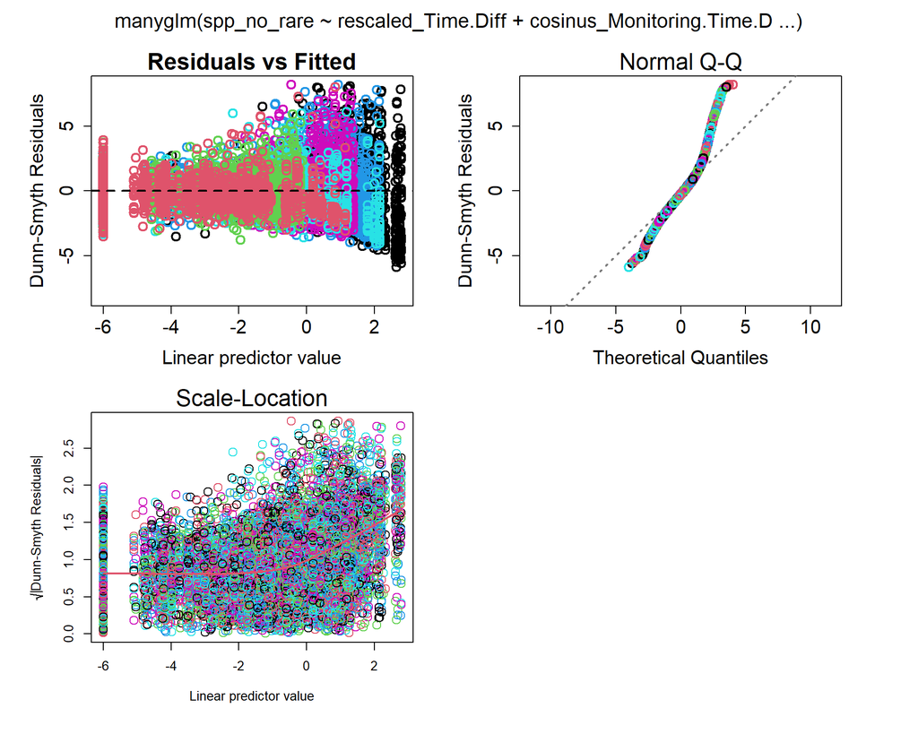

```r
plot(mva_m0.po, which=1:3)
```

```r
print("NEGATIVE BINOMIAL")
```

```
## [1] "NEGATIVE BINOMIAL"
```

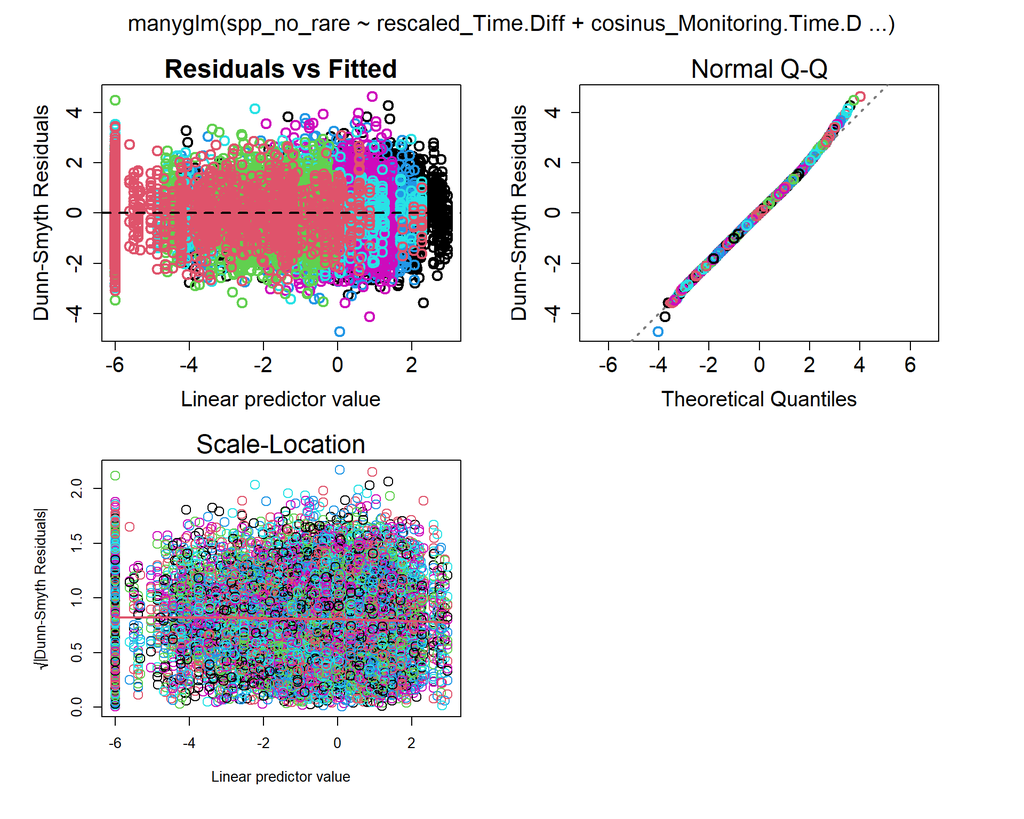

```r
plot(mva_m0.nb, which=1:3)
```

prefer negative binomial because standardized residuals are smaller.

```r
mva_m1 <- manyglm(formula = spp_no_rare ~ Distance_rescaled * rescaled_Time.Diff + cosinus_Monitoring.Time.Diff + sinus_Monitoring.Time.Diff, data = env_data)
aic_dt$nb1 <- mva_m1$aic
colMeans(aic_dt)
```

```
##        nb        po       nb1
##  5515.036 10118.838  5921.207
```

```r
mva_m2 <- manyglm(formula = spp_no_rare ~ Distance_rescaled * rescaled_Time.Diff + cosinus_Monitoring.Time.Diff + sinus_Monitoring.Time.Diff + Site, data = env_data)
aic_dt$nb2 <- mva_m2$aic
colMeans(aic_dt)
```

```
##        nb        po       nb1       nb2
##  5515.036 10118.838  5921.207  5481.673
```

```r
mva_m3 <- manyglm(formula = spp_no_rare ~ Distance_rescaled * rescaled_Time.Diff + cosinus_Monitoring.Time.Diff + sinus_Monitoring.Time.Diff + Unit, data = env_data)
aic_dt$nb3 <- mva_m2$aic
colMeans(aic_dt)
```

```
##        nb        po       nb1       nb2       nb3
##  5515.036 10118.838  5921.207  5481.673  5481.673
```

##Many GLM with site

```r
mva_m0.nb.site <- manyglm(formula = spp_no_rare ~ rescaled_Time.Diff + cosinus_Monitoring.Time.Diff + sinus_Monitoring.Time.Diff + Site, family = "negative.binomial", data = env_data)
drop1(mva_m0.nb.site)
```

```
## Single term deletions
##
## Model:
## spp_no_rare ~ rescaled_Time.Diff + cosinus_Monitoring.Time.Diff +
##     sinus_Monitoring.Time.Diff + Site
##                               Df   AIC
## <none>                           33018
## rescaled_Time.Diff             6 33063
## cosinus_Monitoring.Time.Diff   6 33016
## sinus_Monitoring.Time.Diff     6 33011
## Site                         312 36065
```

Dropped sin time

```r
mva_m2_site <- manyglm(formula = spp_no_rare ~ rescaled_Time.Diff + cosinus_Monitoring.Time.Diff + Site, family = "negative.binomial", data = env_data)
drop1(mva_m2_site)
```

```
## Single term deletions
##
## Model:
## spp_no_rare ~ rescaled_Time.Diff + cosinus_Monitoring.Time.Diff +
##     Site
##                               Df   AIC
## <none>                           33011
## rescaled_Time.Diff             6 33054
## cosinus_Monitoring.Time.Diff   6 33008
## Site                         312 36065
```

Dropped cosin time

```r
mva_m2_site <- manyglm(formula = spp_no_rare ~ rescaled_Time.Diff + Site, family = "negative.binomial", data = env_data)
drop1(mva_m2_site)
```

```
## Single term deletions
##
## Model:
## spp_no_rare ~ rescaled_Time.Diff + Site
##                     Df   AIC
## <none>                 33008
## rescaled_Time.Diff   6 33053
## Site               312 36132
```

```r
# mva_m2 <- manyglm(formula = spp_no_rare ~ rescaled_Time.Diff + Site, family = "negative.binomial", data = env_data)
# drop1(mva_m2)
```

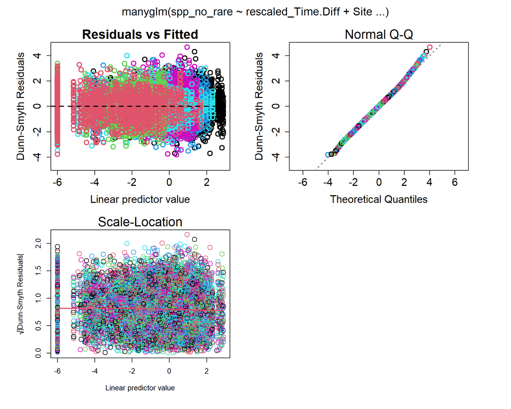

```r
plot(mva_m2_site, which=1:3)
```

```r
#summ_m2_site <- summary(mva_m2_site)
summ_m2_site <- readRDS("../output/national/manyglm_national_site.RDS")
print(summ_m2_site)
```

```
##
## Test statistics:
##                             wald value Pr(>wald)
## (Intercept)                      6.442     0.001 ***
## rescaled_Time.Diff               7.981     0.001 ***
## SiteAderet_maquis                1.965     0.495
## SiteAmatzia                      3.200     0.052 .
## SiteBat Shlomo                   1.721     0.470
## SiteBeer Milka                   5.028     0.001 ***
## SiteBeit Oren                    6.233     0.001 ***
## SiteBeit Yatir                   5.420     0.001 ***
## SiteBislach                      6.484     0.001 ***
## SiteEin Yaakov                   9.115     0.001 ***
## SiteEin Yahav                    5.547     0.001 ***
## SiteEitanim                      2.744     0.166
## SiteElyakim                      4.563     0.001 ***
## SiteEshtaol                      3.802     0.008 **
## SiteEzuz                         6.257     0.001 ***
## SiteGamla                        6.268     0.001 ***
## SiteGivat Yearim                 7.052     0.001 ***
## SiteGivat Yeshayahu_conifer      2.285     0.232
## SiteGivat Yeshayahu_maquis       3.451     0.044 *
## SiteGoren                        6.974     0.001 ***
## SiteHar Amasa                    6.928     0.001 ***
## SiteIftach                       1.981     0.467
## SiteKabri                        4.442     0.003 **
## SiteKarei Deshe                  5.273     0.001 ***
## SiteKerem Maharal_conifer        6.103     0.001 ***
## SiteKerem Maharal_maquis         3.637     0.026 *
## SiteKfar Shamai                  5.344     0.001 ***
## SiteKisalon                      6.527     0.001 ***
## SiteLahav                        5.008     0.003 **
## SiteLehavim                      5.958     0.001 ***
## SiteLotan                        4.987     0.001 ***
## SiteManara                       2.530     0.190
## SiteMargaliot                    7.119     0.001 ***
## SiteMerhav Am                    4.132     0.007 **
## SiteMeron                        5.240     0.001 ***
## SiteMirsham                      4.026     0.013 *
## SiteNatur                        4.943     0.001 ***
```

[output cut: 9 more lines]

```
## SiteShaal                        5.145     0.001 ***
## SiteShunra                       3.195     0.013 *
## SiteYagur                        3.922     0.009 **
## SiteYavneel                      5.134     0.001 ***
## SiteYeruham                      3.543     0.039 *
## SiteYotvata                      6.769     0.001 ***
## SiteZofar                        9.541     0.001 ***
## SiteZuriel                       4.607     0.001 ***
## ---
## Signif. codes:  0 '***' 0.001 '**' 0.01 '*' 0.05 '.' 0.1 ' ' 1
##
## Test statistic:  50.02, p-value: 0.001
## Arguments:
##  Test statistics calculated assuming response assumed to be uncorrelated
##  P-value calculated using 999 resampling iterations via pit.trap resampling (to account for correlation in testing).
```

```r
#saveRDS(summ_m2_site, "output/national/manyglm_national_site.RDS")
#anov_m2.uni_site <- anova(mva_m2_site, p.uni = "adjusted")
#saveRDS(anov_m2.uni_site, "output/national/Anova_national_site.RDS")
anov_m2.uni_site <- readRDS("../output/national/Anova_national_site.RDS")
print(anov_m2.uni_site)
```

```
## Analysis of Deviance Table
##
## Model: spp_no_rare ~ rescaled_Time.Diff + Site
##
## Multivariate test:
##                    Res.Df Df.diff  Dev Pr(>Dev)
## (Intercept)          2846
## rescaled_Time.Diff   2845       1   57    0.001 ***
## Site                 2793      52 3748    0.001 ***
## ---
## Signif. codes:  0 '***' 0.001 '**' 0.01 '*' 0.05 '.' 0.1 ' ' 1
##
## Univariate Tests:
##                    Canis.aureus          Canis.lupus          Hyaena.hyaena
##                             Dev Pr(>Dev)         Dev Pr(>Dev)           Dev
## (Intercept)
## rescaled_Time.Diff        3.967    0.268       4.723    0.268         0.032
## Site                    864.327    0.001     288.689    0.001       408.713
##                             Hystrix.indica          Lepus.capensis
##                    Pr(>Dev)            Dev Pr(>Dev)            Dev Pr(>Dev)
## (Intercept)
## rescaled_Time.Diff    0.865          1.577    0.401         37.065    0.002
## Site                  0.001        937.476    0.001        737.376    0.001
##                    Vulpes.vulpes
##                              Dev Pr(>Dev)
## (Intercept)
## rescaled_Time.Diff         9.259    0.066
## Site                     511.752    0.001
## Arguments:
##  Test statistics calculated assuming uncorrelated response (for faster computation)
## P-value calculated using 999 iterations via PIT-trap resampling.
```

**Multivariate test shows that site and time difference significantly affect species composition**

```r
coefp_site <- merge(data.table(t(coef(mva_m2_site)/log(2)),keep.rownames=TRUE), data.table(t(anov_m2.uni_site$uni.p), keep.rownames = TRUE), by = "rn") # coefficients are exponentiated because the link function used for poisson is log -> above 1 is positive and below 1 is negative
# add total species abundance
coefp_site <- merge(coefp_site,as.data.table(colSums(spp_no_rare),keep.rownames = TRUE), by.x = "rn", by.y = "V1")

#colnames(coefp_site) <- c("SciName","Intercept.coef","Time_diff.coef","Cosin_time.coef","Sin_time.coef","Herbaceous_dwarf_shrub.coef","Inland_sands.coef","MD_tranzition_zone.coef","Maquis.coef","Negev_highlands.coef", "Conifer.coef", "Intercept.p","Time_diff.p","Cosin_time.p","Sin_time.p","Site.p","species_abundance")

write.csv(coefp_site, "../output/national/coefficients_National_data_Sites.csv")

print(coefp_site)
```

```
##                rn (Intercept).x rescaled_Time.Diff.x SiteAderet_maquis
## 1:   Canis.aureus     0.5892395           0.13356072       -0.04927447
## 2:    Canis.lupus   -21.2616084           0.58456165        0.01492914
## 3:  Hyaena.hyaena    -2.4838729           0.04440587        1.08772417
## 4: Hystrix.indica     1.5914167           0.24559761       -0.61251939
## 5: Lepus.capensis   -21.2826867           0.47519502        0.01213742
## 6:  Vulpes.vulpes     1.0389891           0.19911382       -0.20179090
##    SiteAmatzia SiteBat Shlomo SiteBeer Milka SiteBeit Oren SiteBeit Yatir
## 1:  1.16228752    -1.08459023     -2.6361442    1.81673702      0.5695684
## 2: 17.59983587     0.09765853     -0.4822812    0.08461204     -0.2890857
## 3: -1.52657477   -18.87441435     -1.8861776    0.63621381     -1.5374971
## 4: -1.39232534     0.01722503    -23.1209749   -0.45226529     -7.6759704
## 5: 16.17420149     0.07938883     19.4201959    0.06878323     20.4784434
## 6:  0.04461213     0.01975294     -0.7062648   -2.60541757      0.2791712
##    SiteBislach SiteEin Yaakov SiteEin Yahav SiteEitanim SiteElyakim SiteEshtaol
```

[output cut: 76 more lines]

Time is only significant for Lepus capensis, single species model includes only sites with at least 1 observation

```r
# Subset by sites
sites2keep <- all.mammal.abundances[,sum(`Lepus capensis`),keyby=Site][V1>0,Site]
Lepus.subset.Sites <- all.mammal.abundances[Site %in% sites2keep][,`:=`(Site=factor(Site))]
dim(Lepus.subset.Sites)
```

```
## [1] 1248   40
```

```r
#Lepus.capensis <- spp_no_rare[,"Lepus.capensis"]
glm.Lepus.capensis <- glm.nb(formula = `Lepus capensis` ~ rescaled_Time.Diff + Site, data = Lepus.subset.Sites)
coef(glm.Lepus.capensis)
```

```
##                 (Intercept)          rescaled_Time.Diff
##                  -3.5409337                   0.3293851
##              SiteBeer Milka              SiteBeit Yatir
##                   2.2499506                   2.9834733
##                 SiteBislach               SiteEin Yahav
##                   3.0969293                   5.4242033
##                    SiteEzuz SiteGivat Yeshayahu_conifer
##                   3.6200143                   0.8882346
##  SiteGivat Yeshayahu_maquis               SiteHar Amasa
##                   1.5485600                   2.9717393
##                   SiteLahav                 SiteLehavim
##                  -0.4640941                   3.9837691
##                   SiteLotan               SiteMerhav Am
##                   2.4711826                   1.7445277
##                 SiteMirsham              SiteNir Etzion
##                   0.7045864                  -0.7406729
##            SiteOfer_conifer                   SiteParan
##                   3.3357122                   3.2135838
##               SiteSde Boker                  SiteSecher
##                   2.1527023                   2.7317290
##                  SiteShunra                 SiteYeruham
##                   1.9679140                   2.7428287
##                 SiteYotvata                   SiteZofar
##                   2.2238379                   4.3077456
```

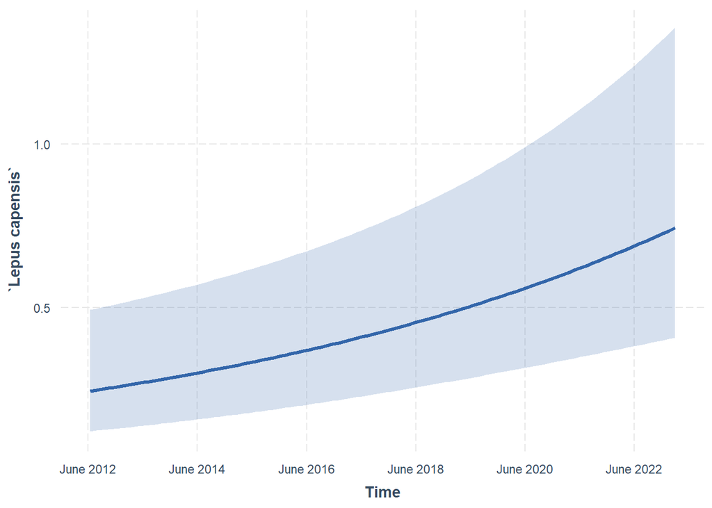

```r
effect_plot(model = glm.Lepus.capensis, data=Lepus.subset.Sites, pred = rescaled_Time.Diff, interval = T, plot.points = F, jitter = c(0.1,0),
            partial.residuals = F, colors = "Qual1", at = list(Site="Yeruham")) +
  scale_x_continuous(breaks=c(-1.86423,-1.233466888,-0.601840099,0.028922631,0.66054942,1.291312151),
                     labels=c("June 2012", "June 2014", "June 2016", "June 2018", "June 2020", "June 2022"), name = "Time")
```

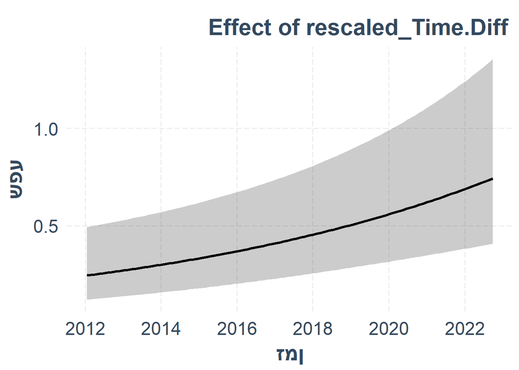

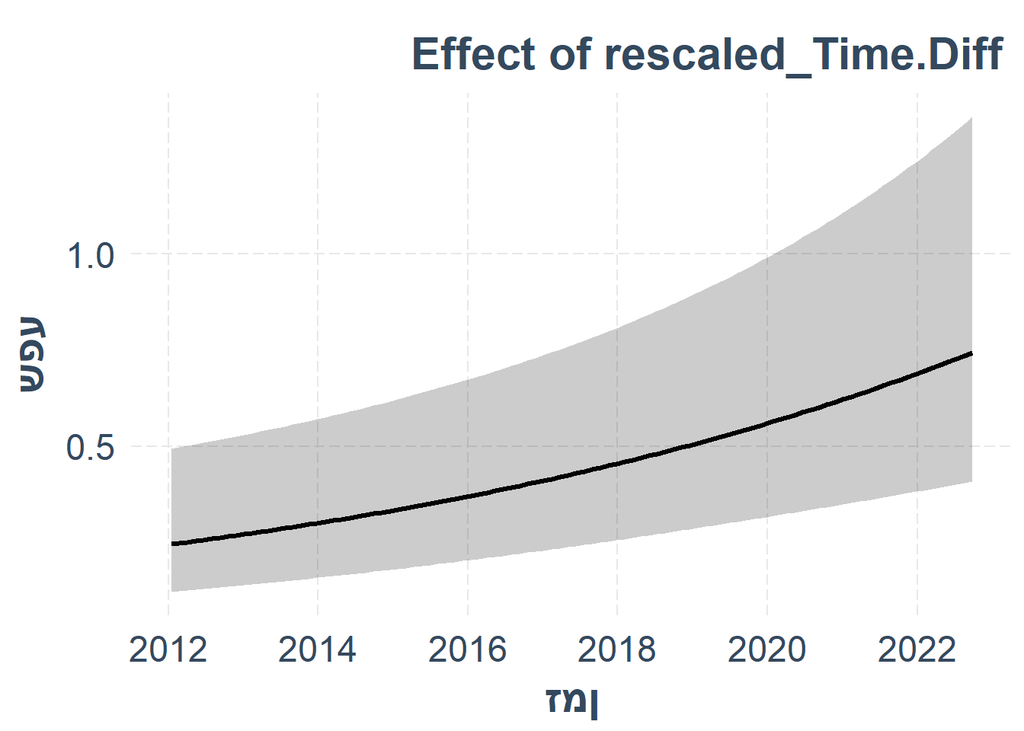

```r
plot_model_effect(P.anal = Lepus.subset.Sites, m = glm.Lepus.capensis, eff2plot = "rescaled_Time.Diff", plot_points=FALSE, plot_residuals=FALSE, export_plot=TRUE, ylabel = NULL,
                  fontname = "Almoni ML v5 AAA", fontsize=22, pdf_width=160, outpath = "../output/national/", at_list = list(Site="Yeruham"))
```

# Analysis of only far transects

```r
only.far <- P.anal[grepl("Far",Settlements) | grepl("Far", Agriculture),][order(Unit,Site)]
dim(only.far)
```

```
## [1] 1815   43
```

```r
print(nrow(only.far[Unit == "Arid Desert"]))
```

```
## [1] 165
```

```r
print(nrow(only.far[Unit == "Herbaceous and Dwarf Shrub Vegetation"]))
```

```
## [1] 181
```

```r
print(nrow(only.far[Unit == "Inland Sands"]))
```

```
## [1] 85
```

```r
print(nrow(only.far[Unit == "Mediterranean Desert Transition Zone"]))
```

```
## [1] 139
```

```r
print(nrow(only.far[Unit == "Mediterranean Maquis"]))
```

```
## [1] 545
```

```r
print(nrow(only.far[Unit == "Negev Highlands"]))
```

```
## [1] 149
```

```r
print(nrow(only.far[Unit == "Planted Conifer Forests"]))
```

```
## [1] 551
```

# Species filtering - national species + minimum 40 cameras

```r
abundance_and_cameras_far <- as.data.table(only.far[,c(5,27:40)])
dim(abundance_and_cameras_far)
```

```
## [1] 1815   15
```

```r
canisau <- abundance_and_cameras_far[,2] > 0
sum(canisau)
```

```
## [1] 786
```

```r
canislup <- abundance_and_cameras_far[,3] > 0
sum(canislup)
```

```
## [1] 66
```

```r
Hyaena <- abundance_and_cameras_far[,9] > 0
sum(Hyaena)
```

```
## [1] 218
```

```r
Hystrix <- abundance_and_cameras_far[,10] > 0
sum(Hystrix)
```

```
## [1] 590
```

```r
Lepus <- abundance_and_cameras_far[,11] > 0
sum(Lepus)
```

```
## [1] 162
```

```r
Vulpus <- abundance_and_cameras_far[,15] > 0
sum(Vulpus)
```

```
## [1] 834
```

1815 cameras total,

Species for national analyses + a minimum of 40 cameras - Canis aureus, Canis lupus, Hyaena hyaena, Hystrix indica, Lepus capensis and vulpus vulpus

```r
spp_no_rare_far <- only.far[,27:40]
print(colSums(spp_no_rare_far))
```

```
##      Canis aureus       Canis lupus     Capra nubiana Dama mesopotamica
##              4148               334               404               244
##    Equus hemionus    Gazella dorcas   Gazella gazella     Hyaena hyaena
##                76               767              1900               353
##    Hystrix indica    Lepus capensis       Meles meles     Oryx leucoryx
##              1963               642               230                72
##        Sus scrofa     Vulpes vulpes
##              6372              2399
```

```r
# filter out species
spp_no_rare_far <- mvabund(spp_no_rare_far[,c(-3:-7,-11:-13)])
print(colSums(spp_no_rare_far))
```

```
##   Canis.aureus    Canis.lupus  Hyaena.hyaena Hystrix.indica Lepus.capensis
##           4148            334            353           1963            642
##  Vulpes.vulpes
##           2399
```

Left with 6 species

```r
env_data_far <- only.far[,..col_names]

mva_m0.po.far <- manyglm(formula = spp_no_rare_far ~ rescaled_Time.Diff + cosinus_Monitoring.Time.Diff + sinus_Monitoring.Time.Diff + Site + Unit, family = "poisson", data = env_data_far)

mva_m0.nb.far <- manyglm(formula = spp_no_rare_far ~ rescaled_Time.Diff + cosinus_Monitoring.Time.Diff + sinus_Monitoring.Time.Diff + Site + Unit, family = "negative.binomial", data = env_data_far)

aic_dt <- data.table(nb = mva_m0.nb.far$aic, po=mva_m0.po.far$aic)
colMeans(aic_dt)
```

```
##       nb       po
## 3191.120 5035.036
```

```r
print("POISSON")
```

```
## [1] "POISSON"
```

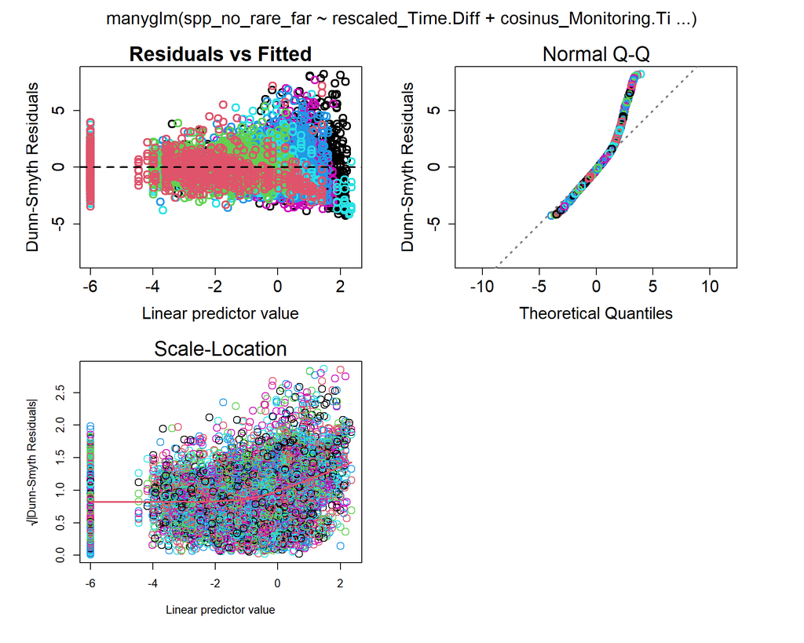

```r
plot(mva_m0.po.far, which=1:3)
```

```r
print("NEGATIVE BINOMIAL")
```

```
## [1] "NEGATIVE BINOMIAL"
```

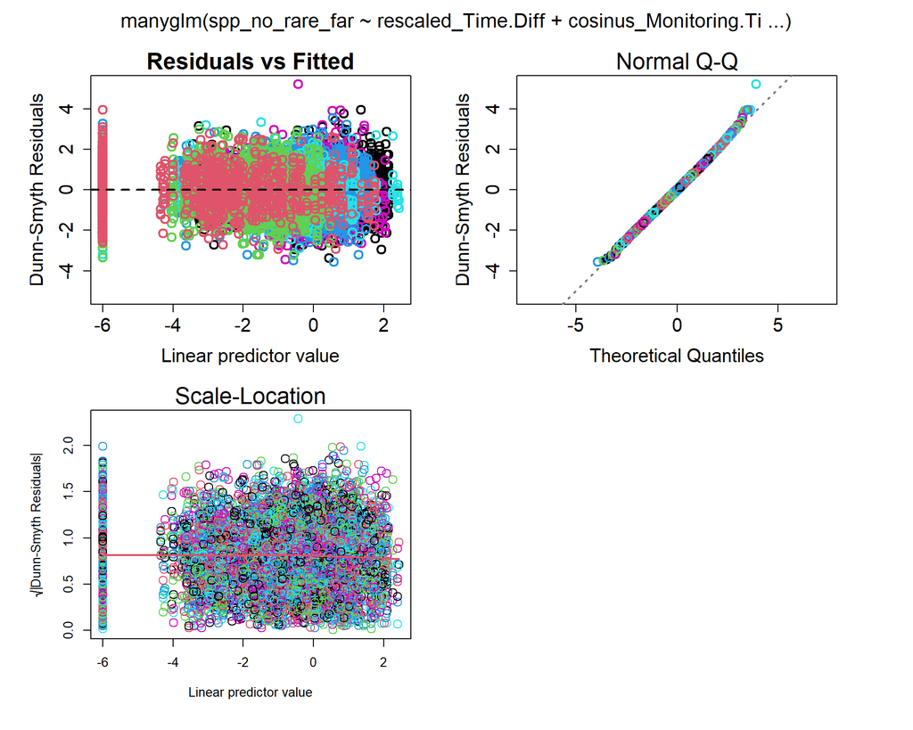

```r
plot(mva_m0.nb.far, which=1:3)
```

prefer negative binomial because standardized residuals are smaller.

```r
mva_m1_far <- manyglm(formula = spp_no_rare_far ~ Distance_rescaled * rescaled_Time.Diff + cosinus_Monitoring.Time.Diff + sinus_Monitoring.Time.Diff, data = env_data_far)
aic_dt$nb1 <- mva_m1_far$aic
colMeans(aic_dt)
```

```
##       nb       po      nb1
## 3191.120 5035.036 3438.618
```

```r
mva_m2_far <- manyglm(formula = spp_no_rare_far ~ Distance_rescaled * rescaled_Time.Diff + cosinus_Monitoring.Time.Diff + sinus_Monitoring.Time.Diff + Site, data = env_data_far)
aic_dt$nb2 <- mva_m2_far$aic
colMeans(aic_dt)
```

```
##       nb       po      nb1      nb2
## 3191.120 5035.036 3438.618 3178.131
```

```r
mva_m3_far <- manyglm(formula = spp_no_rare_far ~ Distance_rescaled * rescaled_Time.Diff + cosinus_Monitoring.Time.Diff + sinus_Monitoring.Time.Diff + Unit, data = env_data_far)
aic_dt$nb3 <- mva_m3_far$aic
colMeans(aic_dt)
```

```
##       nb       po      nb1      nb2      nb3
## 3191.120 5035.036 3438.618 3178.131 3316.762
```